# Important time series operators

22 February 2023

## Important operators

This slide deck defines these 2 important operators:

- *backshift shift operator* (\(\mathbf{B}\))
- *difference operator* (\(\nabla\))

## The backshift shift operator

The *backshift shift operator* (\(\mathbf{B}\)) is an important function in time series analysis, which we define as

\[ \mathbf{B} x_t = x_{t-1} \]

or more generally as

\[ \mathbf{B}^k x_t = x_{t-k} \]

## The backshift shift operator

For example, a random walk with

\[ x_t = x_{t-1} + w_t \]

can be written as

\[ \begin{align} x_t &= \mathbf{B} x_t + w_t \\ x_t - \mathbf{B} x_t &= w_t \\ (1 - \mathbf{B}) x_t &= w_t \\ x_t &= (1 - \mathbf{B})^{-1} w_t \end{align} \]

## The difference operator

The *difference operator* (\(\nabla\)) is another important function in time series analysis, which we define as

\[ \nabla x_t = x_t - x_{t-1} \]

## The difference operator

The *difference operator* (\(\nabla\)) is another important function in time series analysis, which we define as

\[ \nabla x_t = x_t - x_{t-1} \]

For example, first-differencing a random walk yields white noise

\[ \begin{align} \nabla x_t &= x_{t-1} + w_t \\ x_t - x_{t-1} &= x_{t-1} + w_t - x_{t-1}\\ x_t - x_{t-1} &= w_t\\ \end{align} \]

## Differencing a biased random walk

First-differencing a biased random walk yields a constant mean (level) \(u\) plus white noise

\[ \begin{align} \nabla x_t &= x_{t-1} + u + w_t \\ x_t - x_{t-1} &= x_{t-1} + u + w_t - x_{t-1} \\ x_t - x_{t-1} &= u + w_t \end{align} \]

## Differencing a biased random walk

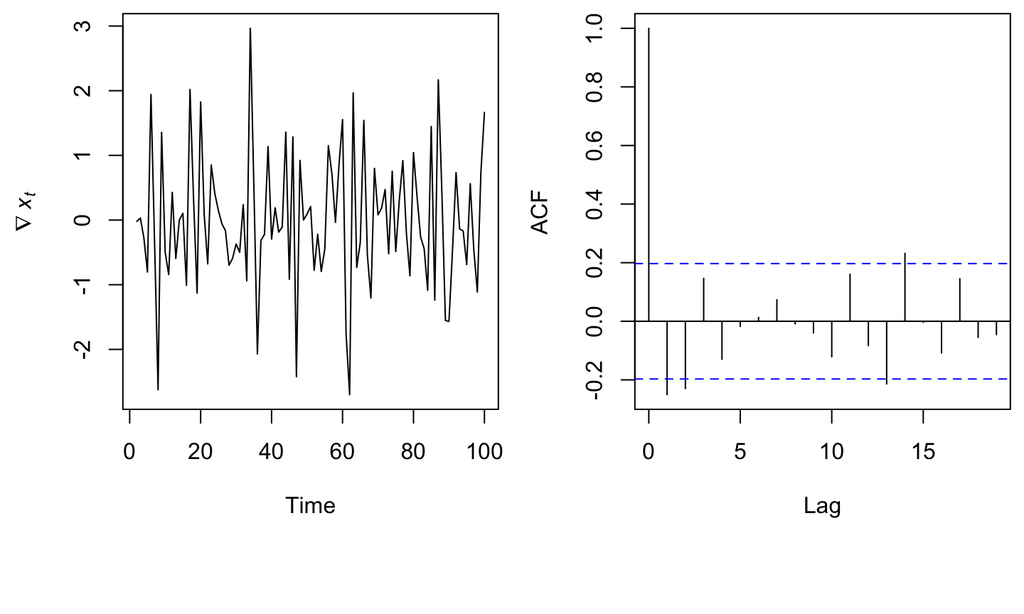

## The difference operator

The difference operator and the backshift operator are related

\[ \nabla^k = (1 - \mathbf{B})^k \]

## The difference operator

The difference operator and the backshift operator are related

\[ \nabla^k = (1 - \mathbf{B})^k \]

For example

\[ \begin{align} \nabla x_t &= (1 - \mathbf{B})x_t \\ x_t - x_{t-1} &= x_t - \mathbf{B} x_t \\ x_t - x_{t-1} &= x_t - x_{t-1} \end{align} \]

## Differencing to remove a trend

Differencing is a simple means for removing a trend

The 1st-difference removes a linear trend; a 2nd-difference would remove a quadratic trend, etc.

## Differencing to remove a trend

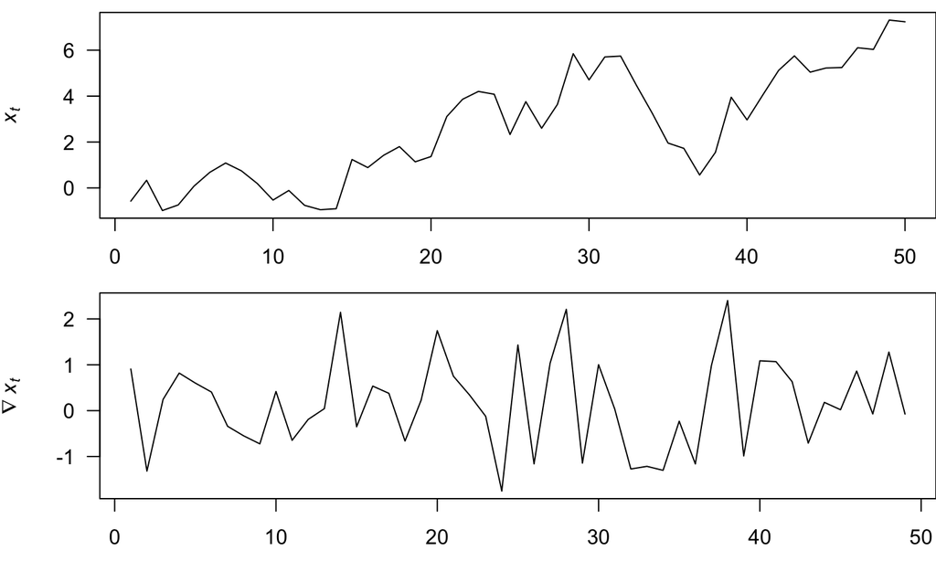

## Differencing to remove seasonality

Differencing is a simple means for removing a seasonal effect

Using a 1st-difference with \(k = period\) removes both trend & seasonal effects

## Differencing to remove seasonality

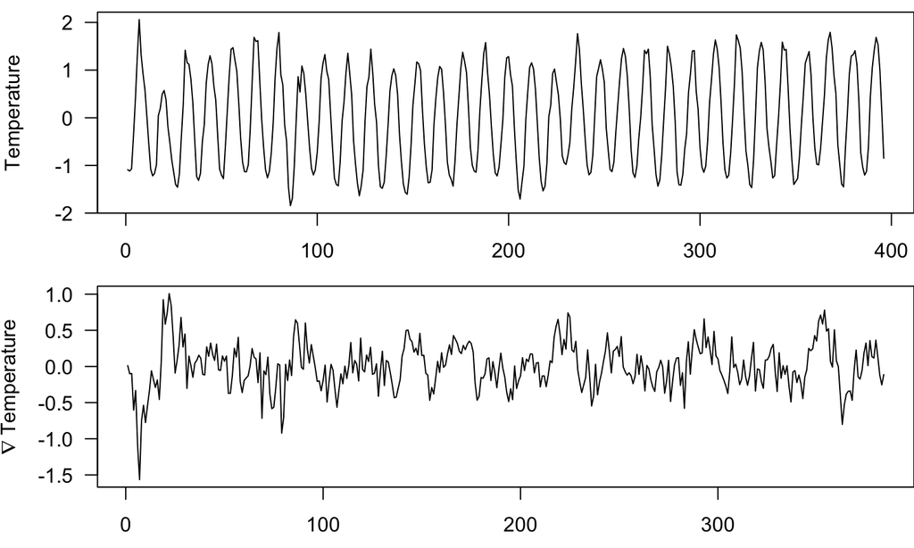